# Assignment: Temporal Diversity

Matt Gibson; Z620: Quantitative Biodiversity, Indiana University

## OVERVIEW

In this Assignment, we extend our understanding of diversity from the spatial dimension to the temporal dimension.

After completing this exercise you will know how to:

1. wrangle a large dataset to visualize and analyze time series data
2. test hypotheses from experiments with temporal data
3. quantify temporal $\beta$-diversity and stability

## Directions:

1. Change “Student Name” on line 3 (above) with your name.
2. Complete as much of the exercise as possible during class; what you do not complete in class will need to be done on your own outside of class.
3. Use the Handout as a guide; it contains a more complete description of data sets along with the proper scripting needed to carry out the exercise.
4. Be sure to **answer the questions** in this exercise document; they also correspond to the Handout. Space for your answer is provided in this document and indicated by the “>” character. If you need a second paragraph be sure to start the first line with “>”.
5. Before you leave the classroom, **push** this file to your GitHub repo.
6. When you are done with the Assignment, **Knit** the text and code into a html file.
7. After Knitting, please submit the completed Assignment by creating a **pull request** via GitHub. Your pull request should include this file *temporal_assignment.Rmd* and the html output of `Knitr` (*temporal_assignment.html*).

## 1) R SETUP

Typically, the first thing you will do in either an R script or an RMarkdown file is setup your environment. This includes things such as setting the working directory and loading any packages that you will need.

In the R code chunk below, provide the code to:

1. clear your R environment,
2. print your current working directory,
3. set your working directory to your “*/Week5-Temporal*” folder, and
4. load any packages you need to complete the assignment.

```r
rm(list=ls())
getwd()
```

```
## [1] "C:/Users/matth/Documents/bin/QB2017_Gibson/Week5-Temporal"
```

```r
setwd("c:/Users/matth/Documents/bin/QB2017_Gibson/Week5-Temporal")

package.list <- c('vegan', 'tidyr', 'dplyr', 'codyn', 'ggplot2',
                 'MullerPlot', 'RColorBrewer', 'reshape2', 'lubridate',
                  'TTR', 'xtable', 'multcomp', 'pander', 'png', 'grid', 'tseries', 'nlme',
                  'forecast', 'lsmeans','vegan', 'ade4', 'viridis', 'gplots', 'BiodiversityR', 'indicspecies')
library(BiodiversityR)
library(indicspecies)
library(MullerPlot)
for (package in package.list){
  if (!require(package, character.only=T, quietly=T)){
    install.packages(package, repos="http://cran.us.r-project.org")
    library(package, character.only=T)
  }
}
```

## 2) LOADING DATA

### Load dataset

In the R code chunk below, do the following:

1. load the `portal` dataset from in the “*/Week5/data*” folder, and
2. explore the structure of the dataset.

```r
portal <- read.table("data/combined.csv", sep=",", header=T)

str(portal)
```

```
## 'data.frame':    34786 obs. of  13 variables:
##  $ record_id      : int  1 72 224 266 349 363 435 506 588 661 ...
##  $ month          : int  7 8 9 10 11 11 12 1 2 3 ...
##  $ day            : int  16 19 13 16 12 12 10 8 18 11 ...
##  $ year           : int  1977 1977 1977 1977 1977 1977 1977 1978 1978 1978 ...
##  $ plot_id        : int  2 2 2 2 2 2 2 2 2 2 ...
##  $ species_id     : Factor w/ 48 levels "AB","AH","AS",..: 16 16 16 16 16 16 16 16 16 16 ...
##  $ sex            : Factor w/ 3 levels "","F","M": 3 3 1 1 1 1 1 1 3 1 ...
##  $ hindfoot_length: int  32 31 NA NA NA NA NA NA NA NA ...
##  $ weight         : int  NA NA NA NA NA NA NA NA 218 NA ...
##  $ genus          : Factor w/ 26 levels "Ammodramus","Ammospermophilus",..: 13 13 13 13 13 13 13 13 13 13 ...
##  $ species        : Factor w/ 40 levels "albigula","audubonii",..: 1 1 1 1 1 1 1 1 1 1 ...
##  $ taxa           : Factor w/ 4 levels "Bird","Rabbit",..: 4 4 4 4 4 4 4 4 4 4 ...
##  $ plot_type      : Factor w/ 5 levels "Control","Long-term Krat Exclosure",..: 1 1 1 1 1 1 1 1 1 1 ...
```

```r
dplyr::count(portal, plot_id)
```

```
## # A tibble: 24 × 2
##    plot_id     n
##      <int> <int>
## 1        1  1989
## 2        2  2191
## 3        3  1808
## 4        4  1960
## 5        5  1150
## 6        6  1562
## 7        7   729
## 8        8  1881
## 9        9  1929
## 10      10   324
## # ... with 14 more rows
```

```r
dplyr::count(portal, species)
```

```
## # A tibble: 40 × 2
##            species     n
##             <fctr> <int>
## 1         albigula  1252
## 2        audubonii    75
## 3          baileyi  2891
## 4        bilineata   303
## 5  brunneicapillus    50
## 6        chlorurus    39
## 7           clarki     1
## 8         eremicus  1299
## 9           flavus  1597
## 10      fulvescens    75
## # ... with 30 more rows
```

*Question 1*: Describe some of the attributes of the `portal` dataset.

1. How many plots are in `portal`?
2. How many rodent species are there in the `portal` dataset?

## 3) WRANGLING THE PORTAL DATASET

In the R code chunk below, do the following:

1. Create a site-by-species matrix for any year of your choosing.
2. Create a vector of plot_type for sites in the site-by-species matrix.
3. Analyze alpha diversity (e.g., Shannon/Simpson) across the sites for that year.
4. Create a PCoA ordination of your site-by-species matrix.
5. Using the hypothesis testing tools you learned in the beta-diversity module, test the hypothesis that species abundances across sites vary as a factor of treatment type (i.e., plot_type).

```r
portal <- unite(portal, col=date, c(year, month, day), sep = "-", remove=F)
portal <- unite(portal, col = taxon, c(genus, species), sep = "_", remove=F)

time.by.species <- group_by(portal, year, plot_id, plot_type) %>%
  count(taxon) %>% spread(key = taxon, value = n, fill = 0)
time.by.species <- as.data.frame(time.by.species)

matrix <- dplyr::filter(time.by.species, year == 1984)
matrix <- as.data.frame(matrix)

siteBySpecies <- matrix[,4:50]

############################Calculate shannon diversity using vegan######################################
print(shannon <- diversity(siteBySpecies, index = "shannon"))
```

```
##  [1] 1.3652619 2.0160552 2.1048747 0.8861713 1.3552517 1.8036086 0.7963116
##  [8] 1.4610630 1.4565878 0.6615632 1.7010410 1.9192314 1.6307278 1.5499932
## [15] 1.9432443 1.2634795 1.3386461 1.6974928 1.3534969 1.6755192 1.3316643
## [22] 1.5395696 1.2852930 1.5797406
```

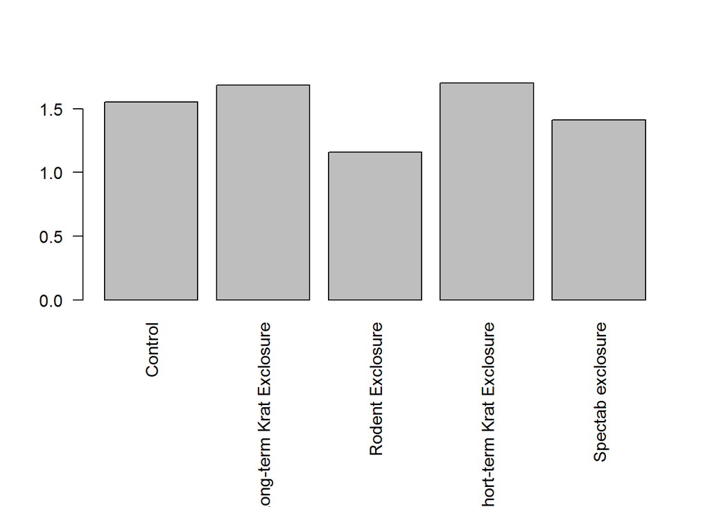

```r
siteShannon <- cbind(as.data.frame(matrix[,3]), as.data.frame(shannon))


a <- aggregate(shannon ~ matrix[, 3], data=siteShannon, FUN=mean)
op <- par(mar = c(10,4,4,2) + 0.1)

barplot(a$shannon, names.arg=a$`matrix[, 3]`, las=2)
```

```r
par(op) ## reset

#PCoA
species.db <- vegdist(siteBySpecies, method = "bray", diag = T)
species.pcoa <- cmdscale(species.db, eig=T, k = 3)


explainvar1 <- round(species.pcoa$eig[1] / sum(species.pcoa$eig), 3) * 100
explainvar2 <- round(species.pcoa$eig[2] / sum(species.pcoa$eig), 3) * 100
explainvar3 <- round(species.pcoa$eig[3] / sum(species.pcoa$eig), 3) * 100
sum.eig <- sum(explainvar1, explainvar2, explainvar3)

#Variance explained by first axis
explainvar1
```

```
## [1] 56.3
```

```r
#variance explained by second axis
explainvar2
```

```
## [1] 12.3
```

```r
#variance explained by third axis
explainvar3
```

```
## [1] 8.8
```

```r
sum.eig
```

```
## [1] 77.4
```

```r
par(mar = c(5, 5, 1, 2) + 0.1)

plot(species.pcoa$points[ ,1], species.pcoa$points[ ,2], ylim = c(-0.2, 0.7),
     xlab = paste("PCoA 1 (", explainvar1, "%)", sep = ""),
     ylab = paste("PCoA 2 (", explainvar2, "%", sep = ""),
     pch = 16, cex = 2.0, type = "n", cex.lab = 1.5, cex.axis = 1.2, axes = F)

axis(side = 1, labels = T, lwd.ticks = 2, cex.axis = 1.2, las = 1)
axis(side = 2, labels = T, lwd.ticks = 2, cex.axis = 1.2, las = 1)
abline(h = 0, v = 0, lty = 3)
box(lwd = 2)

points(species.pcoa$points[ ,1], species.pcoa$points[ ,2],
       pch = 19, cex = 3, bg = "gray", col = "gray")
text(species.pcoa$points[ ,1], species.pcoa$points[ ,2],
     labels = row.names(species.pcoa$points))


speciesREL <- siteBySpecies
  for(i in 1:nrow(siteBySpecies)){
    speciesREL[i, ] = siteBySpecies[i, ]/ sum(siteBySpecies[i, ])
  }

species.pcoa <- add.spec.scores(species.pcoa, speciesREL, method = "pcoa.scores")
```

[output not shown]

[output cut: 106 more lines]

[output not shown]